# How to classify an eamil as spam

Author

Group 25: Hang Cheng, Haowei Yan, Weijan Li, Wenli Lyu, Zehao Wang

# 1 Introductions

Spam has caused some distress in people’s daily life, so identifying spam correctly becomes more and more important nowadays. This study aims to finding Which text characteristics influence whether an email will be classified as spam or not by analyzing the data shared with the UCI Machine Learning Repository.

# 2 Data Reading

```r
# Load the necessary package
library(tidyverse)
library(moderndive)
library(gapminder)
library(sjPlot)
library(stats)
library(jtools)
library(skimr)
```

```r
# Read CSV data
d25 <- read.csv("dataset25.csv")
library(ggplot2)
```

## 2.1 Summary of the Data

```r
d25 %>% skim()
```

Data summary

| Name | Piped data |
| --- | --- |
| Number of rows | 921 |
| Number of columns | 7 |
| _______________________ |  |
| Column type frequency: |  |
| character | 1 |
| numeric | 6 |
| ________________________ |  |
| Group variables | None |

**Variable type: character**

| skim_variable | n_missing | complete_rate | min | max | empty | n_unique | whitespace |
| --- | --- | --- | --- | --- | --- | --- | --- |
| yesno | 0 | 1 | 1 | 1 | 0 | 2 | 0 |

**Variable type: numeric**

| skim_variable | n_missing | complete_rate | mean | sd | p0 | p25 | p50 | p75 | p100 | hist |
| --- | --- | --- | --- | --- | --- | --- | --- | --- | --- | --- |
| crl.tot | 0 | 1 | 275.76 | 491.47 | 1 | 41 | 102.00 | 267.00 | 3752.00 | ▇▁▁▁▁ |
| dollar | 0 | 1 | 0.08 | 0.28 | 0 | 0 | 0.00 | 0.06 | 5.30 | ▇▁▁▁▁ |
| bang | 0 | 1 | 0.29 | 0.88 | 0 | 0 | 0.04 | 0.33 | 19.13 | ▇▁▁▁▁ |
| money | 0 | 1 | 0.08 | 0.32 | 0 | 0 | 0.00 | 0.00 | 6.66 | ▇▁▁▁▁ |
| n000 | 0 | 1 | 0.11 | 0.40 | 0 | 0 | 0.00 | 0.00 | 5.45 | ▇▁▁▁▁ |
| make | 0 | 1 | 0.11 | 0.30 | 0 | 0 | 0.00 | 0.00 | 2.77 | ▇▁▁▁▁ |

Summary of the Data

```r
d25.spam <- d25 %>%
  select(yesno,crl.tot,dollar,bang,money,n000,make)
d25.spam$yesno <- as.factor(d25.spam$yesno)
```

## 2.2 Data Visualization

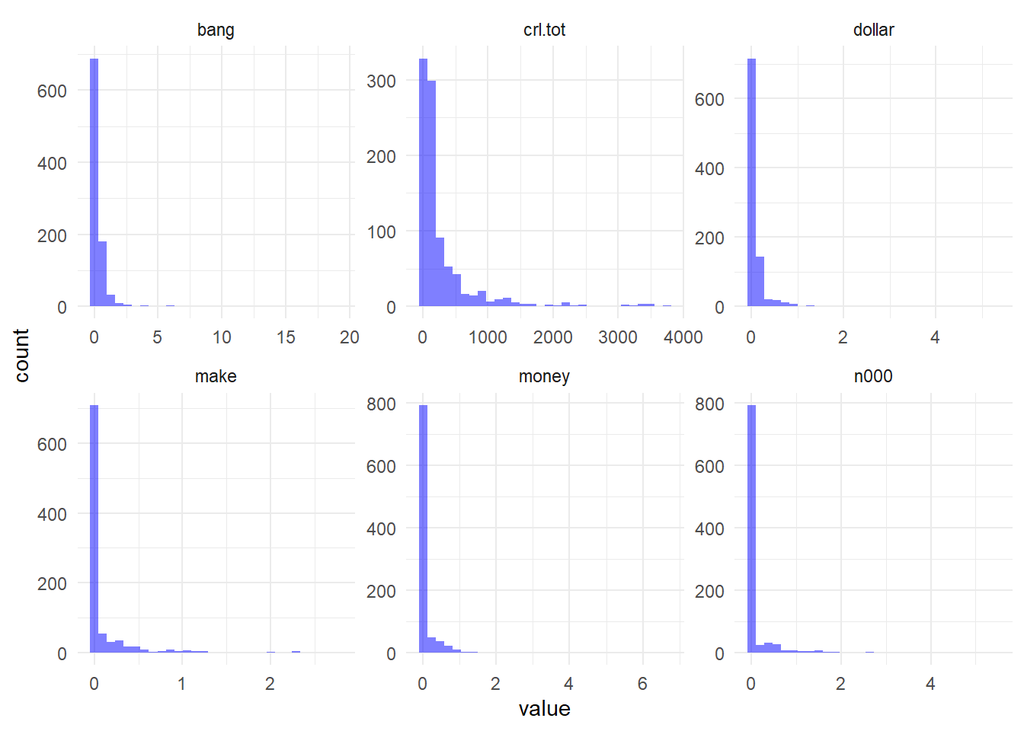

Data Visualization

```r
d25.spam %>%
  pivot_longer(cols = c(crl.tot, dollar, bang, money, n000, make), names_to = "variable", values_to = "value") %>%
  ggplot(aes(x = value)) +
  geom_histogram(bins = 30, fill = "blue", alpha = 0.5) +
  facet_wrap(~variable, scales = "free") +
  theme_minimal()
```

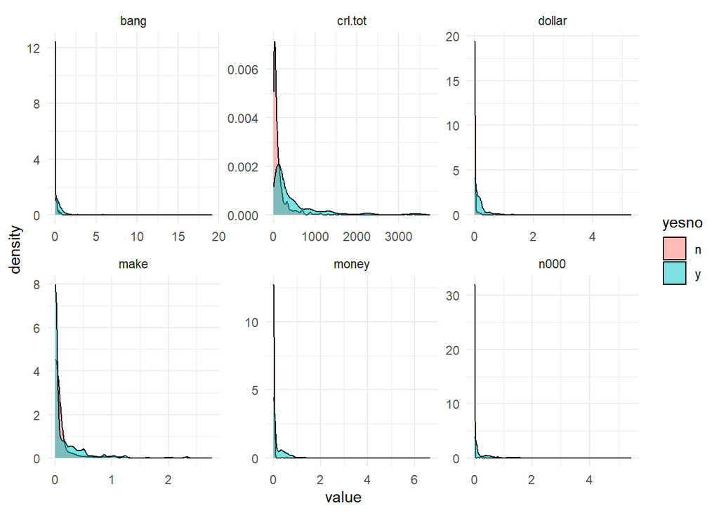

```r
d25.spam %>%
  pivot_longer(cols = c(crl.tot, dollar, bang, money, n000, make), , names_to = "variable", values_to = "value") %>%
  ggplot(aes(x = value, fill = yesno)) +
  geom_density(alpha = 0.5) +
  facet_wrap(~variable, scales = "free") +
  theme_minimal()
```

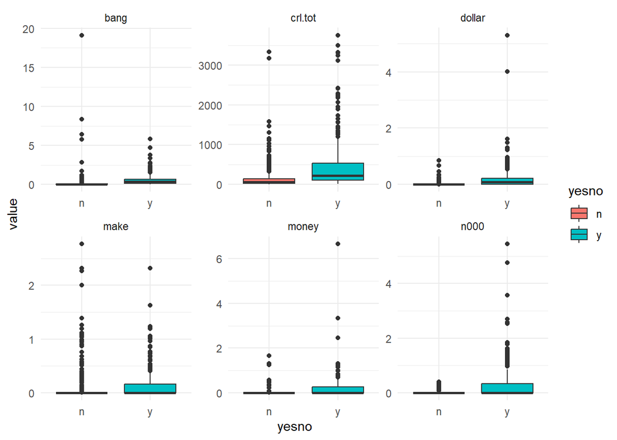

```r
d25.spam %>%
  pivot_longer(cols = c(crl.tot, dollar, bang, money, n000, make), , names_to = "variable", values_to = "value") %>%
  ggplot(aes(x = yesno, y = value, fill = yesno)) +
  geom_boxplot() +
  facet_wrap(~variable, scales = "free") +
  theme_minimal()
```

## 2.3 Data Transform

```r
d25.spam <- d25.spam %>%
  mutate(across(c(crl.tot, dollar, bang, money, n000, make), scale))
```

According to the data, six main characteristics may exert an influence on classifying an email as spam.

# 3 Regression Results of the Data by using Generalized Linear Models

```r
model.spam <- glm(yesno ~ crl.tot + dollar + bang + money + n000 + make, data = d25.spam, family = binomial(link = "logit"))

model.spam %>%
  summary()
```

```
Call:
glm(formula = yesno ~ crl.tot + dollar + bang + money + n000 +
    make, family = binomial(link = "logit"), data = d25.spam)

Coefficients:
            Estimate Std. Error z value Pr(>|z|)
(Intercept) 0.317661   0.148708   2.136   0.0327 *
crl.tot     0.647432   0.143137   4.523 6.09e-06 ***
dollar      1.938311   0.337508   5.743 9.30e-09 ***
bang        0.643314   0.160399   4.011 6.05e-05 ***
money       1.139483   0.224955   5.065 4.08e-07 ***
n000        2.197779   0.479594   4.583 4.59e-06 ***
make        0.004066   0.092900   0.044   0.9651
---
Signif. codes:  0 '***' 0.001 '**' 0.01 '*' 0.05 '.' 0.1 ' ' 1

(Dispersion parameter for binomial family taken to be 1)

    Null deviance: 1241.77  on 920  degrees of freedom
Residual deviance:  809.54  on 914  degrees of freedom
AIC: 823.54

Number of Fisher Scoring iterations: 7
```

The coefficients of six characteristics are all positive, suggesting that spam tends to have more of these text characteristics. All the coefficients of the characteristics, except ‘make’, are significant because of the low p-values. Then we can obtain the effect of these characteristics by looking at the exponential values.

# 4 Residual Analysis

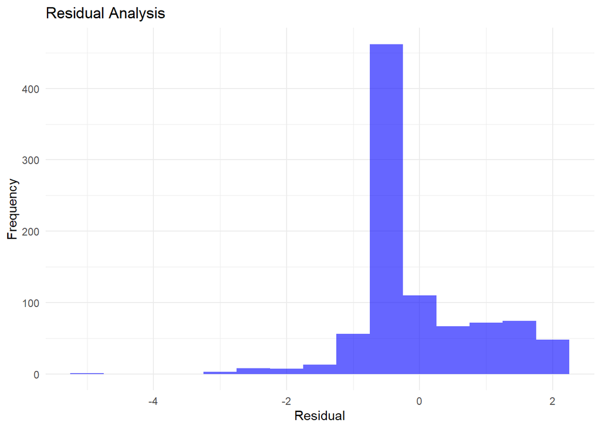

```r
d25.spam$residuals <- residuals(model.spam, type = "deviance")

ggplot(d25.spam, aes(x = residuals)) +
  geom_histogram(binwidth = 0.5, fill = "blue", alpha = 0.6) +
  labs(title = "Residual Analysis", x = "Residual", y = "Frequency") +
  theme_minimal()
```

This residual analysis plot shows the residual is skewed distribution, it may not completely follow the normal distribution. This means that the model has systematic errors in some intervals.

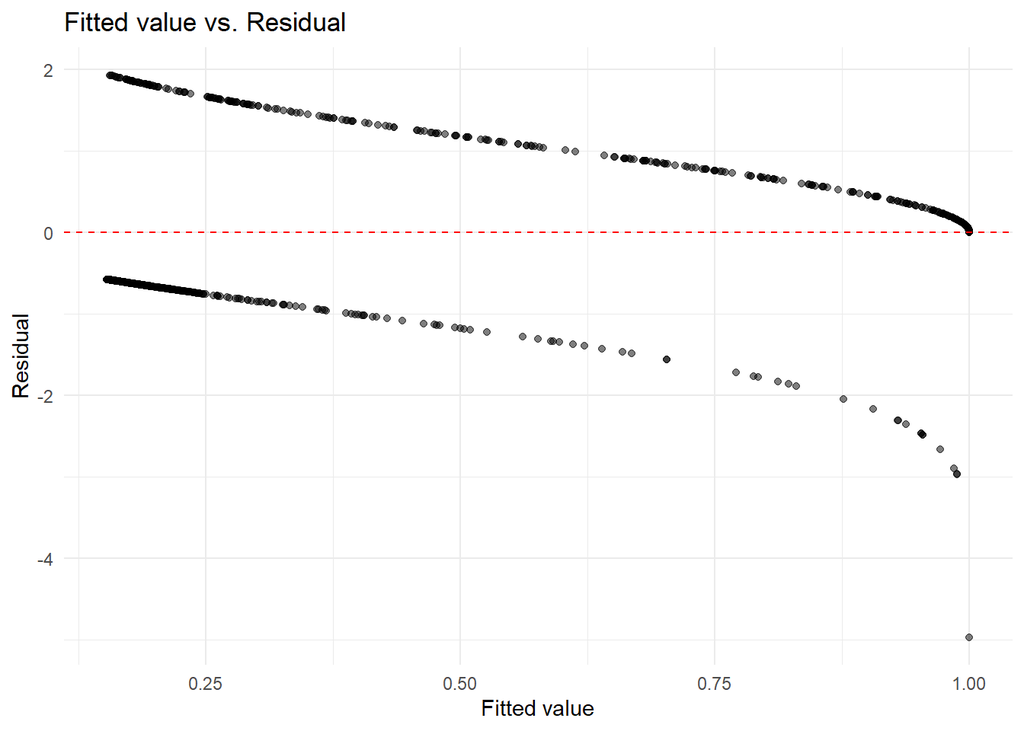

```r
ggplot(d25.spam, aes(x = fitted(model.spam), y = residuals)) +
  geom_point(alpha = 0.5) +
  geom_hline(yintercept = 0, linetype = "dashed", color = "red") +
  labs(title = "Fitted value vs. Residual", x = "Fitted value", y = "Residual") +
  theme_minimal()
```

This plot indicates that the residual are not randomly distributed, but show a systematic trend. Meanwhile, this plot means that the model has larger prediction errors for certain ranges, which may affect the reliability of the confidence interval.

# 5 Data Summary

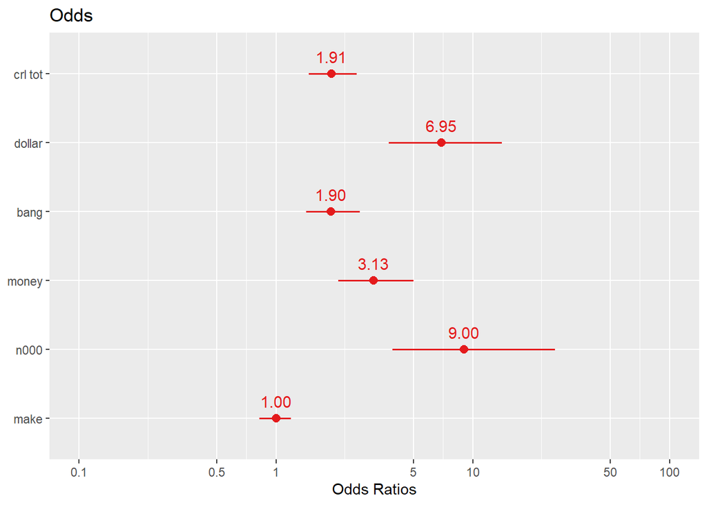

Odds of classifying emails as spam

```r
plot_model(model.spam, show.values = TRUE, title = "Odds", show.p = FALSE, value.offset = 0.25)
```

# 6 Conclusions